# Scrapping Data in R

Nana Boateng

December 23, 2017

** Introduction Web Scraping ** Web scraping is a technique for converting the data present in unstructured format (HTML tags) over the web to the structured format which can easily be accessed and used.

Most of the data available over the web is not readily available. It is present in an unstructured format (HTML format) and is not downloadable. Therefore, it requires knowledge & expertise to use this data.

```r
pacman::p_load(tidyverse,tidytext,viridis,rvest)
```

```r
page <- read_html("https://scholar.google.com/citations?user=JgDKULMAAAAJ")
page
```

```r
citations = page%>% html_nodes(".gsc_a_t")%>%html_text()
citations[1:5]
```

```r
FCAglassdoor <- read_html("https://www.glassdoor.com/Reviews/FCA-Fiat-Chrysler-Automobiles-Reviews-E149.htm")
FCAglassdoor1 = FCAglassdoor%>% html_nodes(".hreview")%>%html_text()
FCAglassdoor1%>%head()

FCAindeed <- read_html("https://www.indeed.com/cmp/Fca-Group-LLC/reviews")
FCAindeed1 = FCAindeed%>% html_nodes("#cmp-content")%>%html_text()
FCAindeed1[[1]][[1]]
```

```r
#Data-Preprocessing: removing '\n'
FCAindeed2<-gsub("\n","",FCAglassdoor1)



#remove all round brackets
FCAindeed2<-FCAindeed2%>%str_replace_all("\\(|\\)", "")

#remove all \\
FCAindeed2<-FCAindeed2%>%str_replace_all("\\\\", "")


#remove all non words and non numbers
#FCAindeed2<-FCAindeed2%>%str_replace_all("[^A-Za-z0-9]", "")

#remove all •
FCAindeed2<-FCAindeed2%>%str_replace_all("\\•  ", "")

#remove all &
FCAindeed2<-FCAindeed2%>%str_replace_all("\\ & ", "")

#remove all  non printable words
FCAindeed2<-FCAindeed2%>%str_replace_all("[^[:print:]]", "")

FCAindeed2<-FCAindeed2%>%gsub(pattern = "\\ /", replacement = "")
#FCAindeed2<-FCAindeed2%>%stringi::stri_unescape_unicode()

FCAindeed2
```

```r
n=4

#The reviews has 155 pages,thus n=155

FCA_urls <- paste0("https://www.glassdoor.com/Reviews/FCA-Fiat-Chrysler-Automobiles-Reviews-E149_P",seq(2, n), ".htm")
FCA_urls<-c("https://www.glassdoor.com/Reviews/FCA-Fiat-Chrysler-Automobiles-Reviews-E149.htm",FCA_urls)


FCA_html <- FCA_urls %>%
    map_chr(~ read_html(.) %>% html_node(".hreview")%>%html_text())

FCA_html[[1]]
```

```r
get_sentiments(lexicon = "nrc")%>%
    count(sentiment, sort = TRUE)
```

Convert the text data to dataframe.

```r
GlassdoorPages <- data_frame(page = seq(1, n),
                      text = c(FCA_html))

GlassdoorPages
```

Now we have the letters, and can convert this to a tidy text format.

```r
tidy_FCA <- GlassdoorPages %>%
    unnest_tokens(word, text) %>%
  dplyr::summarise(n=n())
tidy_FCA


tidy_FCA <- GlassdoorPages %>%
    unnest_tokens(word, text) %>%
   summary(n=count())
tidy_FCA

tidy_FCA <- GlassdoorPages %>%
    unnest_tokens(word, text) %>%
    add_count(page) %>%
    dplyr::rename(page_total = n)



#remove stop words

data("stop_words")
tidy_FCA <- tidy_FCA %>%
  anti_join(stop_words)


tidy_FCA%>%head()
```

Next, let’s implement the sentiment analysis.

```r
FCA_sentiment <- tidy_FCA %>%
    inner_join(get_sentiments("nrc"))

FCA_sentiment%>%head()
```

```r
 GlassdoorPages %>%
unnest_tokens(word, text, token = "sentences")
```

| page | word |
| --- | --- |
| 1 | featured review helpful (1)"love the company has taught me a lot of new information in my contained growth as a mechanic"starstarstarstarstarcurrent employee - service technician in dayton, ohcurrent … |
| 1 | i get to work on the new cars and technology in the automotive fieldconsno cons as of yet, i love the work i do.and the folk i work with. plan on staying with the company through retirementadvice to m… |
| 1 | flag as inappropriateflag as inappropriatehelpful (1) fca fiat chrysler automobiles response seconds ago edit • delete fca fiat chrysler automobiles 2017-09-30 21:14 pdt |
| 2 | nov 12, 2017"financial analyst"starstarstarstarstarwork/life balanceculture & valuescareer opportunitiescomp & benefitssenior managementcurrent employee - financial analystcurrent employee - financial… |
| 2 | working in the big company comes with flexible compensation packages. |
| 2 | competitive car company in the competitive industry. |
| 2 | consturnover rate of the employeement is the cons. |
| 2 | need to work on maintaining the experienced work force to stay for the company. |
| 2 | share on facebookshare on twittershare on whatsappshare via emailcopy linklink copied! |
| 2 | flag as inappropriateflag as inappropriatehelpful (0) fca fiat chrysler automobiles response seconds ago edit • delete fca fiat chrysler automobiles 2017-11-12 16:39 pst |

[output cut: 977 more lines]

```r
 GlassdoorPages %>%
unnest_tokens(word, text,token = "skip_ngrams", n = 4, k = 2)
```

| page | word |
| --- | --- |
| 1 | featured 1 company me |
| 1 | review love has a |
| 1 | helpful the taught lot |
| 1 | 1 company me of |
| 1 | love has a new |
| 1 | the taught lot information |
| 1 | company me of in |
| 1 | has a new my |
| 1 | taught lot information contained |
| 1 | me of in growth |

[output cut: 990 more lines]

```r
 GlassdoorPages %>%
unnest_tokens(word, text, token = "ngrams", n = 2)
```

| page | word |
| --- | --- |
| 1 | featured review |
| 1 | review helpful |
| 1 | helpful 1 |
| 1 | 1 love |
| 1 | love the |
| 1 | the company |
| 1 | company has |
| 1 | has taught |
| 1 | taught me |
| 1 | me a |

[output cut: 990 more lines]

```r
tidy_descr_ngrams=GlassdoorPages %>%
unnest_tokens(word, text, token = "ngrams", n = 2) %>%
filter(!grepl("\\.|http",word)) %>%
separate(word, c("word1", "word2"), sep = " ") %>%
filter(!word1 %in% stop_words$word) %>%
filter(!word2 %in% stop_words$word)
tidy_descr_ngrams
```

[output not shown]

[output cut: 990 more lines]

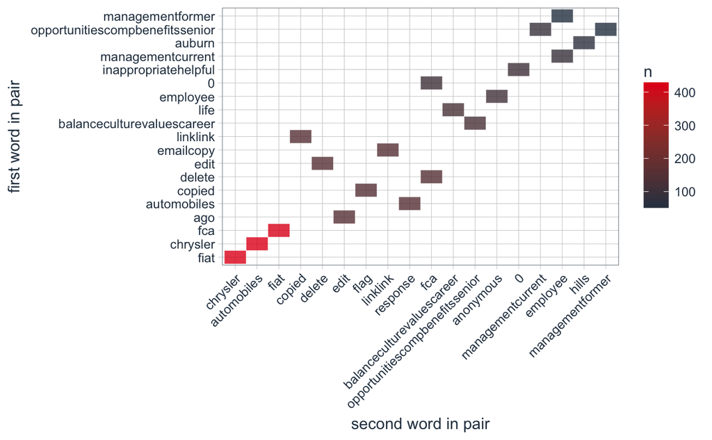

```r
bigram_counts=tidy_descr_ngrams %>%
count(word1, word2, sort = TRUE)
bigram_counts %>%
filter(n > 50) %>%
ggplot(aes(x = reorder(word1,-n), y = reorder(word2,-n), fill = n)) +
geom_tile(alpha = 0.8, color = "white") +
scale_fill_gradientn(colours = c(palette_light()[[1]], palette_light()[[2]])) +
coord_flip() +
theme_tq() +
theme(legend.position = "right") +
theme(axis.text.x = element_text(angle = 45, vjust = 1, hjust = 1)) +
labs(x = "first word in pair",
y = "second word in pair")
```

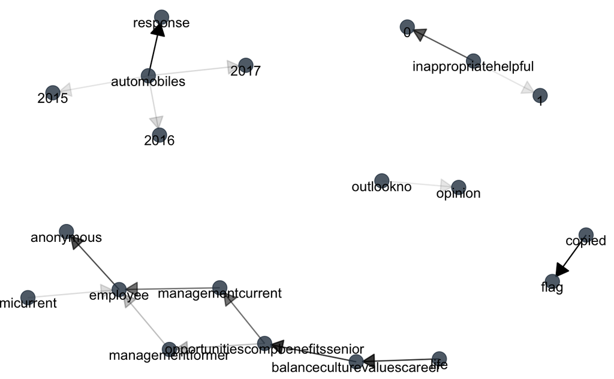

```r
library(igraph)
library(ggraph)
bigram_graph =bigram_counts %>%
filter(n > 30) %>%
graph_from_data_frame()
set.seed(1)
a=grid::arrow(type = "closed", length = unit(.15, "inches"))
ggraph(bigram_graph, layout = "fr") +
geom_edge_link(aes(edge_alpha = n), show.legend = FALSE,
arrow = a, end_cap = circle(.07, 'inches')) +
geom_node_point(color = palette_light()[1], size = 5, alpha = 0.8) +
geom_node_text(aes(label = name), vjust = 1, hjust = 0.5) +
theme_void()
```

```r
theme_set(theme_bw())

#Alternatively
#FCA_sentiment%>%group_by(page, page_total, sentiment)%>%count()

FCA_sentiment %>%
    count(page, page_total, sentiment) %>%
    filter(sentiment %in% c("positive", "negative",
                            "joy", "trust","fear","sadness"))%>%
    mutate(sentiment = as.factor(sentiment)) %>%
    #ggplot(aes(page, n / page_total, fill = sentiment)) +
     ggplot(aes(page, n / sum(n), fill = sentiment)) +
    geom_area(position = "identity", alpha = 0.5) +
    labs(y = "Relative frequency", x = "Page",
         title = "Sentiment analysis of FCA Glassdoor Reviews",
         subtitle = "Using the nrc lexicon")+theme_bw()+
 scale_fill_manual(values=viridis_pal(option = "D")(6))+
   scale_y_continuous(labels = scales::percent)
```

```r
FCA_sentiment %>%
    count(page, page_total, sentiment) %>%
  #  filter(sentiment %in% c("positive", "negative",  "joy", "trust","fear","sadness"))%>%
  mutate(sentiment = forcats::fct_lump(sentiment, 6))%>%
    #mutate(sentiment = as.factor(sentiment)) %>%
    ggplot(aes(page, n / page_total, fill = sentiment)) +
     #ggplot(aes(page, n / sum(n), fill = sentiment)) +
    geom_area(position = "identity", alpha = 0.5) +
    labs(y = "Relative frequency", x = "Page",
         title = "Sentiment analysis of FCA Glassdoor Reviews",
         subtitle = "Using the nrc lexicon")+theme_bw()+
 scale_fill_manual(values=viridis_pal(option = "D")(7))+
   scale_y_continuous(labels = scales::percent)
```

```r
FCA_sentiment %>%
    count(page, page_total, sentiment) %>%
    filter(sentiment %in% c("positive", "negative",
                            "joy", "trust","fear","sadness"))%>%
    mutate(sentiment = as.factor(sentiment)) %>%
    #ggplot(aes(page, n / page_total, fill = sentiment)) +
     ggplot(aes(x=page,y= n / sum(n), fill = sentiment,height=n / sum(n),group=sentiment)) +
   geom_ridgeline_gradient() +
    labs(y = "Relative frequency", x = "Page",
         title = "Sentiment analysis of FCA Glassdoor Reviews",
         subtitle = "Using the nrc lexicon")+theme_bw()+
 scale_fill_viridis(discrete = TRUE, direction = -1) +
   scale_y_continuous(labels = scales::percent)
#expand x and y limits
#expand_limits(x=c(0,160), y=c(0, 0.0005))
```

```r
tidy_FCA %>%
  inner_join(get_sentiments("afinn")) %>%
  group_by(page) %>%
  summarize(average_sentiment = mean(score), words = n()) %>%
  #filter(words >= 10) %>%
  ggplot(aes(page, average_sentiment)) +
  geom_line() +
  geom_hline(color = "red", lty = 2, yintercept = 0) +
labs(y = "Average AFINN sentiment score", x = "Page",
         title = "Sentiment analysis of FCA Glassdoor Reviews",
         subtitle = "Using the affin lexicon")
```

```r
FCA_sentiment %>%
    count(sentiment, word) %>%
    filter(sentiment %in% c("positive", "negative",
                            "joy", "trust","fear","sadness")) %>%
    group_by(sentiment) %>%
    top_n(10) %>%
    ungroup %>%
    mutate(word = reorder(word, n)) %>%
   mutate(sentiment = as.factor(sentiment))  %>%
    ggplot(aes(word, n, fill = sentiment)) +
    geom_bar(alpha = 0.8, show.legend = FALSE,stat = "identity") +
    coord_flip() +
    scale_y_continuous(expand = c(0,0)) +
    facet_wrap(~sentiment, scales = "free") +
   labs(y = "Total number of occurrences", x = "",
         title = "Sentiment analysis of FCA Glassdoor Reviews",
         subtitle = "Using the nrc lexicon")+theme_bw()+
scale_fill_manual(values=viridis_pal(option = "D")(6))

 # # change text into italics
 #        theme(strip.text = element_text(face = "italic")) +
 #  # strip horizontal  axis labels
 #        theme(axis.title.x=element_blank()) +
 #        theme(axis.ticks.x=element_blank()) +
 #        theme(axis.text.x=element_blank())
```

### Plot without viridis package

```r
FCA_sentiment %>%
    count(page, page_total, sentiment) %>%
    filter(sentiment %in% c("positive", "negative",
                            "joy", "trust","fear","sadness"))%>%
     mutate(sentiment = factor(sentiment, levels = c("negative",
                                                    "positive",
                                                    "joy", "trust","fear","sadness"))) %>%
    ggplot(aes(page, n / page_total, fill = sentiment)) +
    geom_area(position = "identity", alpha = 0.5) +
    labs(y = "Relative frequency", x = NULL,
         title = "Sentiment analysis of FCA Glassdoor Reviews",
         subtitle = "Using the nrc")+theme_bw()
```

#### Using bing Lexicon

```r
FCA_sentiment <- tidy_FCA %>%
    inner_join(get_sentiments("bing"))


FCA_sentiment %>%
    count(page, page_total, sentiment)%>%
    mutate(sentiment = as.factor(sentiment))%>%
    ggplot(aes(page, n / page_total, fill = sentiment)) +
    geom_area(position = "identity", alpha = 0.5) +
    labs(y = "Relative frequency", x = "Page",
         title = "Sentiment analysis of FCA Glassdoor Reviews",
         subtitle = "Using the nrc")+theme_bw()+
# scale_fill_manual(values=viridis_pal(option = "plasma")(2))+
   scale_y_continuous(labels = scales::percent)
```

```r
FCA_sentiment %>%
    count(sentiment, word) %>%
    group_by(sentiment) %>%
    top_n(15) %>%
    ungroup %>%
    mutate(word = reorder(word, n)) %>%
   mutate(sentiment = as.factor(sentiment))  %>%
    ggplot(aes(word, n, fill = sentiment)) +
    geom_col(alpha = 0.8, show.legend = FALSE) +
    coord_flip() +
    scale_y_continuous(expand = c(0,0)) +
    facet_wrap(~sentiment) +
   labs(y = "Total number of occurrences", x = "",
         title = "Sentiment analysis of FCA Glassdoor Reviews",
         subtitle = "Using the bing lexicon")+
#scale_fill_manual(values=viridis_pal(option = "D")(8))+
 scale_fill_viridis(end = 0.75, discrete=TRUE, direction = -1) +
        #scale_x_discrete(expand=c(0.02,0)) +
       # theme(strip.text=element_text(hjust=0)) +
  # change text into italics
       # theme(strip.text = element_text(face = "italic")) +
  # strip horizontal  axis labels
        theme(axis.title.x=element_blank()) +
        theme(axis.ticks.x=element_blank()) +
        theme(axis.text.x=element_blank())+
  theme_minimal(base_size = 13)
```

```r
bing_word_counts <-tidy_FCA %>%
  inner_join(bing) %>%
  count(word, sentiment, sort = TRUE) %>%
  ungroup()

bing_word_counts%>%head()

bing_word_counts %>%
 # filter(n > 1) %>%
  mutate(n = if_else(sentiment == "negative", -n, n)) %>%
  mutate(word = reorder(word, n)) %>%
  ggplot(aes(word, n, fill = sentiment)) +
  geom_bar(stat = "identity") +
  theme(axis.text.x = element_text(angle = 90, hjust = 1)) +
  ylab("Contribution to sentiment")+
#scale_fill_manual(values=viridis_pal(option = "D")(2))
 scale_fill_viridis(end = 0.85, discrete=TRUE, direction = 1)
```

```r
n=4

FCA=list()

for (i in 2:n){

FCA[[1]]=read_html("https://www.glassdoor.com/Reviews/FCA-Fiat-Chrysler-Automobiles-Reviews-E149.htm")%>% html_nodes(".hreview")%>%html_text(trim = TRUE)

FCA[[i]]=read_html(paste("https://www.glassdoor.com/Reviews/FCA-Fiat-Chrysler-Automobiles-Reviews-E149_P",i,".htm",sep = ""))%>% html_nodes(".hreview")%>%html_text(trim = TRUE)

}
```

```r
#FCA1<-FCA%>%map_chr(~ html_text(.))

#FCAglassdoor%>% html_nodes(".hreview")



#sapply(FCA, html_nodes,css=".hreview")%>%unlist()

#FCA[[1]]%>% html_nodes(".hreview")%>%html_text()

data.frame(FCA)
```

#### Scrapping PDF Files

```r
pacman::p_load(pdftools)

txt <- pdf_text("/Users/nanaakwasiabayieboateng/Documents/animal_farm.pdf")

txt[1:2]
```

```r
# first page text
cat(txt[1])

# second page text
cat(txt[2])
```

```r
# Table of contents
toc <- pdf_toc("https://arxiv.org/pdf/1403.2805.pdf%22,%20%221403.2805.pdf")

#toc <- pdf_toc("/Users/nanaakwasiabayieboateng/Documents/Resume-Nana.pdf")
# Show as JSON
json<-jsonlite::toJSON(toc, auto_unbox = TRUE, pretty = TRUE)

# Author, version, etc
info <- pdf_info("https://arxiv.org/pdf/1403.2805.pdf%22,%20%221403.2805.pdf")

# Table with fonts
fonts <- pdf_fonts("https://arxiv.org/pdf/1403.2805.pdf%22,%20%221403.2805.pdf")
```

```r
# Author, version, etc
info <- pdf_info("/Users/nanaakwasiabayieboateng/Documents/Resume-Nana.pdf")

# Table with fonts
fonts <- pdf_fonts("/Users/nanaakwasiabayieboateng/Documents/Resume-Nana.pdf")
info
fonts
```

```r
library("tabulizer")
f <- system.file("examples", "data.pdf", package = "tabulizer")
out1 <- extract_tables(f)
str(out1)

out2 <- extract_tables(f, pages = 1, guess = FALSE, method = "data.frame")
str(out2)
```

### Scrapping Wikipeadia Tables

```r
df.oil <- read_html("https://en.wikipedia.org/wiki/List_of_countries_by_oil_production") %>%
  html_nodes("table") %>%
  .[[1]] %>%
  html_table()
```

One enhancement in this release is the addition of the Loughran and McDonald sentiment lexicon of words specific to financial reporting. Sentiment lexicons are lists of words that are used to assess the emotion or opinion content of text by adding up the sentiment scores of individual words within that text;

```r
library(rvest)
library(pdftools)



get_sentiments("loughran") %>%
    count(sentiment, sort = TRUE)


urls_oldest <- paste0("http://www.berkshirehathaway.com/letters/",
                     seq(1977, 1997), ".html")
html_urls <- c(urls_oldest,
               "http://www.berkshirehathaway.com/letters/1998htm.html",
               "http://www.berkshirehathaway.com/letters/1999htm.html",
               "http://www.berkshirehathaway.com/2000ar/2000letter.html",
               "http://www.berkshirehathaway.com/2001ar/2001letter.html")

letters_html <- html_urls %>%
    map_chr(~ read_html(.) %>%
                html_text())
letters_html[1]
```

```r
urls_newest <- paste0("http://www.berkshirehathaway.com/letters/",
                      seq(2003, 2016), "ltr.pdf")

pdf_urls <- c("http://www.berkshirehathaway.com/letters/2002pdf.pdf",
              urls_newest)

letters_pdf <- pdf_urls %>%
    map_chr(~ pdf_text(.) %>% paste(collapse = " "))

letters <- data_frame(year = seq(1977, 2016),
                      text = c(letters_html, letters_pdf))
```

### Lexicons

**Bing Liu** maintains and freely distributes a sentiment lexicon consisting of lists of strings.

Positive words: 2006 Negative words: 4783 Useful properties: includes mis-spellings, morphological variants, slang, and social-media mark-up

the tidytext package contains three general purpose English sentiment lexicons. The positive or negative meaning of a word can depend on its context, though. A word like “risk” has a negative meaning in most general contexts but may be more neutral for financial reporting. Context-specific sentiment lexicons like the **Loughran-McDonald** dictionary provide a way to deal with this.

This financial lexicon labels words with six possible sentiments.

**NRC Word-Emotion Association Lexicon (aka EmoLex)**

The NRC Emotion Lexicon is a list of English words and their associations with eight basic emotions (anger, fear, anticipation, trust, surprise, sadness, joy, and disgust) and two sentiments (negative and positive). The annotations were manually done by crowdsourcing.

An example I recently saw a sentiment analysis by Michael Toth of Warren Buffett’s letters to shareholders. It’s a super interesting analysis, done well, but we can see from some of the plots in that analysis that the specifically financial nature of these documents would make a financial sentiment lexicon a great choice. Let’s scrape the letters from Berkshire Hathaway, Warren Buffett’s company, and then implement a sentiment analysis using this new lexicon.

```r
get_sentiments(lexicon = c("afinn", "bing", "nrc", "loughran"))

get_sentiments()

get_sentiments("loughran") %>%
    count(sentiment, sort = TRUE)
```

```r
letters
tidy_letters <- letters %>%
    unnest_tokens(word, text) %>%
    add_count(year) %>%
    rename(year_total = n)

tidy_letters

letter_sentiment <- tidy_letters %>%
    inner_join(get_sentiments("loughran"))

letter_sentiment


letter_sentiment %>%
    count(year, year_total, sentiment) %>%
    filter(sentiment %in% c("positive", "negative",
                            "uncertainty", "litigious")) %>%
    mutate(sentiment = factor(sentiment, levels = c("negative",
                                                    "positive",
                                                    "uncertainty",
                                                    "litigious"))) %>%
    ggplot(aes(year, n / year_total, fill = sentiment)) +
    geom_area(position = "identity", alpha = 0.5) +
    labs(y = "Relative frequency", x = NULL,
         title = "Sentiment analysis of Warren Buffett's shareholder letters",
         subtitle = "Using the Loughran-McDonald lexicon")
```

```r
letter_sentiment %>%
    count(sentiment, word) %>%
    filter(sentiment %in% c("positive", "negative",
                            "uncertainty", "litigious")) %>%
    group_by(sentiment) %>%
    top_n(15) %>%
    ungroup %>%
    mutate(word = reorder(word, n)) %>%
    mutate(sentiment = factor(sentiment, levels = c("negative",
                                                    "positive",
                                                    "uncertainty",
                                                    "litigious"))) %>%
    ggplot(aes(word, n, fill = sentiment)) +
    geom_col(alpha = 0.8, show.legend = FALSE) +
    coord_flip() +
    scale_y_continuous(expand = c(0,0)) +
    facet_wrap(~sentiment, scales = "free") +
    labs(x = NULL, y = "Total number of occurrences",
         title = "Words driving sentiment scores in Warren Buffett's shareholder letters",
         subtitle = "From the Loughran-McDonald lexicon")
```

### bigrquery

The bigrquery packages provides an R interface to Google BigQuery. It makes it easy to retrieve metadata about your projects, datasets, tables and jobs, and provides a convenient wrapper for working with bigquery from R.

### Authentication

The first time you use bigrquery in a session, it will ask you to authorize bigrquery in the browser. This gives bigrquery the credentials to access data on your behalf. By default, bigrquery picks up httr’s policy of caching per-working-directory credentials in .httr-oauth.

Note that bigrquery requests permission to modify your data; in general, the only data created or modified by bigrquery are the temporary tables created as query results, unless you explicitly modify your own data (say by calling delete_table() or insert_upload_job()).

```r
pacman::p_load(bigrquery)


#AUTH:AIzaSyCU9XhK6VmHcmrUjaU8xwRm-0rWleEuwiE
#client id::195397749877-rs4mud4m19m8qe0j525828nj6r1h1e0i.apps.googleusercontent.com
#put your project ID here::bigqueryproject1-189300
#secret::OPnLFhJzuq9X_8JJirF3vINd
```

```r
library(bigrquery)
project <- "bigqueryproject1-189300" # put your project ID here
sql <- "SELECT year, month, day, weight_pounds FROM [publicdata:samples.natality] LIMIT 5"
query_exec(sql, project = project)
```

```r
#devtools::install_github("rstats-db/bigrquery")

# install.packages('devtools') devtools::install_github("rstats-db/bigrquery")

# Use your project ID here
project <- "your-project-id" # put your project ID here

# Example query - select copies of files with content containing "TODO"
sql <- "SELECT SUM(copies)
FROM `bigquery-public-data.github_repos.sample_contents`
WHERE NOT binary AND content LIKE '%TODO%'"

# Execute the query and store the result
todo_copies <- query_exec(sql, project = project, useLegacySql = FALSE)
```

```r
library(tm)
#install.packages("SnowballC")
pacman::p_load(SnowballC)
library(wordcloud)

#remove all •
FCAglassdoor2<-FCAglassdoor1%>%str_replace_all("\\•  ", "")

corpus = Corpus(VectorSource(FCAglassdoor2))
corpus = tm_map(corpus, tolower)
#corpus = tm_map(corpus, PlainTextDocument)
corpus = tm_map(corpus, removePunctuation)
corpus = tm_map(corpus, removeNumbers)
corpus = tm_map(corpus, removeWords, stopwords("english"))
corpus = tm_map(corpus, stemDocument)
corpus<- tm_map(corpus, stripWhitespace)
#dtm = TermDocumentMatrix(corpus)
#dtm = removeSparseTerms(dtm, 0.97)
corpus

inspect(corpus[1])

dtm
```

```r
#FCA_html2<-FCA_html%>%str_replace_all("[[:xdigit:]]", "")

corpus = Corpus(VectorSource(FCA_html))

tdm <- TermDocumentMatrix(corpus,
                          control = list(removePunctuation = TRUE,
                                      stopwords =  TRUE,
                                      removeNumbers = TRUE, tolower = TRUE,
                                      PlainTextDocument=TRUE,
                                      stripWhitespace=TRUE, stemming = TRUE))

tdm

inspect(tdm)
#%>%as.data.frame.matrix()%>%arrange(desc(count))

tidy(tdm)
#tdm = tm_map(tdm, removeNumbers)
tdm = as.matrix(tdm)


class(tdm)
dim(tdm)
```

```r
#labeledTerms = as.data.frame(as.matrix(tdm))
```

```r
frequencies = DocumentTermMatrix(corpus)
frequencies
```

```r
findFreqTerms(frequencies, lowfreq=20)
```

Remove sparse terms

```r
sparse = removeSparseTerms(frequencies, 0.995)
sparse
```

What about associations between words? Let’s have a look at what other words had a high association with “love”.

```r
findAssocs(dtm, "love", 0.8)
```

```r
# separating text by emotion
emos = levels(factor(sent_df$emotion))
nemo = length(emos)
emo.docs = rep("", nemo)
for (i in 1:nemo)
{
   tmp = some_txt[emotion == emos[i]]
   emo.docs[i] = paste(tmp, collapse=" ")
}

# remove stopwords
emo.docs = removeWords(emo.docs, stopwords("english"))
# create corpus
corpus = Corpus(VectorSource(emo.docs))
tdm = TermDocumentMatrix(corpus)
tdm = as.matrix(tdm)
colnames(tdm) = emos

# comparison word cloud
comparison.cloud(tdm, colors = brewer.pal(nemo, "Dark2"),
   scale = c(3,.5), random.order = FALSE, title.size = 1.5)
```

```r
library(RColorBrewer)

# comparison word cloud
comparison.cloud(tdm)
```

```r
comparison.cloud(tdm,scale=c(4,.5),max.words=300,
    random.order=FALSE,rot.per=.1,
    colors=viridis_pal(option = "D")(4),
    use.r.layout=FALSE,title.size=3)


# wordcloud(words = d$word, freq = d$freq, min.freq = 1,
#           max.words=200, random.order=FALSE, rot.per=0.35,
#           colors=brewer.pal(8, "Dark2"))
```

### High Frequency Words

```r
v <-sort(rowSums(tdm),decreasing=TRUE)
d <-data_frame(word = names(v),freq=v) %>%mutate(word = reorder(word, freq))
head(d, 10)

wordcloud(words = d$word, freq = d$freq, min.freq = 1,
          max.words=200, random.order=FALSE, rot.per=0.35,
          colors=brewer.pal(8, "Dark2"))

d=d[1:20,]
ggplot(d, aes(x=word,y=freq,fill="")) +
 geom_bar(stat="identity")+theme_bw()+
  theme(axis.text.x =element_text(angle =45,hjust = 1))
#scale_fill_viridis(end = 0.85, discrete=TRUE, direction = 1)
scale_fill_manual(values=viridis_pal(option = "D")(1))
```

### Word Cloud with Bing Lexicon

```r
 GlassdoorPages %>%
    unnest_tokens(word, text)%>%
  inner_join(bing) %>%
  count(word, sentiment, sort = TRUE) %>%
 reshape2::acast(word ~ sentiment, value.var = "n", fill = 0) %>%
  comparison.cloud(colors = viridis_pal(option = "D")(2),
                   max.words = 100)
```

### Word Cloud with nrc Lexicon

```r
GlassdoorPages %>%
    unnest_tokens(word, text)%>%
  inner_join(get_sentiments("nrc")) %>%
  count(word, sentiment, sort = TRUE)%>%
  spread( word,n,fill = 0)
```

```r
GlassdoorPages %>%
    unnest_tokens(word, text)%>%
  inner_join(get_sentiments("nrc")) %>%
  count(word, sentiment, sort = TRUE)%>%
filter(sentiment %in% c("negative","positive","joy","sadness"))%>%
reshape2::acast(word ~ sentiment, value.var = "n", fill = 0)%>%
comparison.cloud(colors = c("#F8766D", "#00BFC4"),
                  max.words = 200)
```

#### Unnesting Sentences.

```r
GlassdoorPages %>%
    unnest_tokens(sentence, text, token = "sentences")%>%
  inner_join(get_sentiments("nrc"),by=c("sentence"="word")) %>%
  count(sentence, sentiment, sort = TRUE)
```

```r
library(xml2)
library(httr)
library(rvest)
library(purrr)
library(dplyr)

to_get <- seq(0, 150, 10)
pb <- progress_estimated(length(to_get))

map_chr(to_get, function(i) {
  pb$tick()$print()
  searchURL <- paste("http://pqasb.pqarchiver.com/djreprints/results.html?st=advanced&QryTxt=bankruptcy&sortby=CHRON&datetype=6&frommonth=01&fromday=01&fromyear=1908&tomonth=12&today=31&toyear=1908&By=&Title=&at_hist=article&at_hist=editorial_article&at_hist=front_page&type=historic&start=", i, sep="")
  htmlWeb <- read_html(searchURL)
  nodeWeb <- html_node(htmlWeb, "td > font.result_title > a")
  textWeb <- html_text(nodeWeb)
  Sys.sleep(sample(10, 1) * 0.1)
  textWeb
}) -> titles

print(trimws(titles))
```

```r
library(rvest)
url = "http://google.com"
download.file(url, destfile = "scrapedpage.html", quiet=TRUE)
content <- read_html("scrapedpage.html")
```

```r
bigrams_separated<-GlassdoorPages%>%
unnest_tokens(word, text, token = "ngrams", n = 2) %>%
filter(!grepl("\\.|http", word)) %>%
separate(word, c("word1", "word2"), sep = " ") %>%
filter(word1 == "not" | word1 == "no") %>%
filter(!word2 %in% stop_words$word)

not_words<-bigrams_separated %>%
filter(word1 == "not") %>%
inner_join(get_sentiments("afinn"), by = c(word2 = "word")) %>%
count(word2, score, sort = TRUE) %>%
ungroup()


tidy_descr_sentiment<-tidy_descr %>%
left_join(select(bigrams_separated, word1, word2), by = c("word" = "word2")) %>%
inner_join(get_sentiments("nrc"), by = "word") %>%
inner_join(get_sentiments("bing"), by = "word") %>%
rename(nrc = sentiment.x, bing = sentiment.y) %>%
mutate(nrc = ifelse(!is.na(word1), NA, nrc),
bing = ifelse(!is.na(word1) & bing == "positive", "negative",
ifelse(!is.na(word1) & bing == "negative", "positive", bing)))

tidy_descr_sentiment %>%
filter(nrc != "positive") %>%
filter(nrc != "negative") %>%
gather(x, y, nrc, bing) %>%
count(x, y, sort = TRUE) %>%
filter(n > 10) %>%
ggplot(aes(x = reorder(y, n), y = n)) +
facet_wrap(~ x, scales = "free") +
geom_col(color = palette_light()[1], fill = palette_light()[1], alpha = 0.8) +
coord_flip() +
theme_tq() +
labs(x = "",
y = "count of sentiment in followers' descriptions")
```